# DS202_Lab3

Dongming Li

9/26/2020

From Imran: Issues: Unnecessary dat again in q1 after init before q1 q5 educ should have as.numeric() labels

Update: remove unnecessary dat in q1 q5 educ does not need as.numeric() cause It has already been numeric in q1: dat1 <- dat1 %>% mutate(educ=as.numeric(educ)) add labels

```r
library(readxl)
library(ggplot2)
library(tidyverse)
library(dplyr)

datum <- readxl::read_xls('GSS.xls')
newdat <- datum %>%
  rename(year=`Gss year for this respondent`,
         marital=`Marital status`,
         educ=`Highest year of school completed`,
         sex=`Respondents sex`,
         partyid=`Political party affiliation`,
         happy=`General happiness`,
         ballot=`Ballot used for interview`,
         id=`Respondent id number`,
         conpress=`Confidence in press`,
         bills=`Income alone is enough`,
         qlife=`R's quality of life`) %>%
  filter(!educ %in% c("No answer", "Don't know")) %>%
  filter(!marital %in% c("No answer")) %>%
  filter(!partyid %in% c("No answer", "Don't know"))

dat <- readxl::read_xls('GSS2.xls')
dat1<-rename(dat,marital=`Marital status`, educ=`Highest year of school completed`, sex=`Respondents sex`, party=`Political party affiliation`, happy=`General happiness`, fincome=`Total family income`, age=`Age of respondent`)
dat1<-dat1%>%filter(educ!="No answer")
dat1<-dat1%>%filter(educ!="Don't know")
dat1<-dat1%>%filter(marital!="No answer")
dat1<-dat1%>%filter(party!="No answer")
dat1<-dat1%>%filter(party!="Don't know")
```

## Exploration

Use ggplot2 to create the plots, and dplyr to manipulate the data frame as much as possible. You may want to rename the columns of the data frame for your convenience using rename in dplyr.

1. Find the average years of education for the respondents with each political party affiliation. Arrange your output in a meaningful order and print. Describe any patterns you find.

```
## # A tibble: 8 x 2
##   party              AVEEDU
##   <chr>               <dbl>
## 1 Ind,near dem         13.2
## 2 Ind,near rep         13.3
## 3 Independent          12.3
## 4 Not str democrat     12.6
## 5 Not str republican   13.3
## 6 Other party          13.4
## 7 Strong democrat      12.5
## 8 Strong republican    13.4
```

```
The output shows the average years of education for each political party affiliation. From the output, in general, we can see Republicans at all levels are better educated than Democrats at the same level. And individuals' education level is a little lower than these two affiliation.
```

2. Create a single data frame containing records for the better educated respondents in each political party affiliation. A “better educated” respondent is someone who has strictly more years of education than the median in the same party affiliation. Print the structure of the data frame.

```r
df1 <- newdat %>%
  mutate(educ=as.numeric(educ)) %>%
  group_by(partyid) %>%
  mutate(median_educ=median(educ, na.rm = TRUE)) %>%
  filter(educ>median_educ) %>%
  ungroup()

str(df1)
```

```
## tibble [27,670 x 12] (S3: tbl_df/tbl/data.frame)
##  $ year       : num [1:27670] 1972 1972 1972 1972 1972 ...
##  $ ballot     : chr [1:27670] "Not applicable" "Not applicable" "Not applicable" "Not applicable" ...
##  $ bills      : chr [1:27670] "Not applicable" "Not applicable" "Not applicable" "Not applicable" ...
##  $ conpress   : chr [1:27670] "Not applicable" "Not applicable" "Not applicable" "Not applicable" ...
##  $ happy      : chr [1:27670] "Not too happy" "Not too happy" "Pretty happy" "Not too happy" ...
##  $ partyid    : chr [1:27670] "Ind,near dem" "Not str democrat" "Ind,near dem" "Ind,near dem" ...
##  $ sex        : chr [1:27670] "Female" "Female" "Male" "Male" ...
##  $ educ       : num [1:27670] 16 17 14 16 13 14 14 17 14 16 ...
##  $ marital    : chr [1:27670] "Never married" "Married" "Never married" "Never married" ...
##  $ id         : num [1:27670] 1 4 6 8 11 16 17 19 20 25 ...
##  $ qlife      : chr [1:27670] "Not applicable" "Not applicable" "Not applicable" "Not applicable" ...
##  $ median_educ: num [1:27670] 13 12 13 13 12 12 13 13 13 13 ...
```

3. How is the happiness of a respondent related to his/her marriage status? Define that a person is happy if the response to question is “Very happy” or “Pretty happy”.

```
## # A tibble: 5 x 2
##   marital       CountHappy
##   <chr>              <int>
## 1 Divorced            7567
## 2 Married            31548
## 3 Never married      12644
## 4 Separated           2055
## 5 Widowed             5741
```

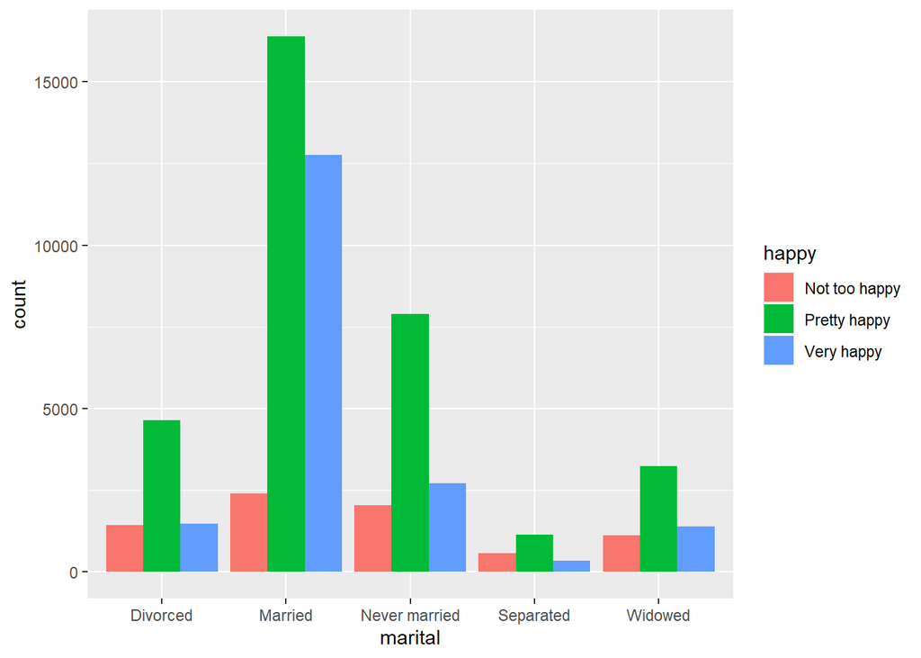

[output not shown]

4. Does party affiliation affect the relationship you found in the last question?

```r
newdat %>%
  select(happy, marital, partyid) %>%
  filter(happy %in% c("Pretty happy", "Very happy")) %>%
  drop_na() %>%
  group_by(marital, partyid) %>%
  summarise(nHappy=n()) %>%
  arrange(desc(nHappy))
```

```
## # A tibble: 40 x 3
## # Groups:   marital [5]
##    marital       partyid            nHappy
##    <chr>         <chr>               <int>
##  1 Married       Not str democrat     5961
##  2 Married       Not str republican   5250
##  3 Married       Strong democrat      4141
##  4 Married       Independent          3919
##  5 Married       Strong republican    3402
##  6 Married       Ind,near dem         3196
##  7 Married       Ind,near rep         2823
##  8 Never married Not str democrat     2254
##  9 Never married Independent          1815
## 10 Never married Ind,near dem         1669
## # ... with 30 more rows
```

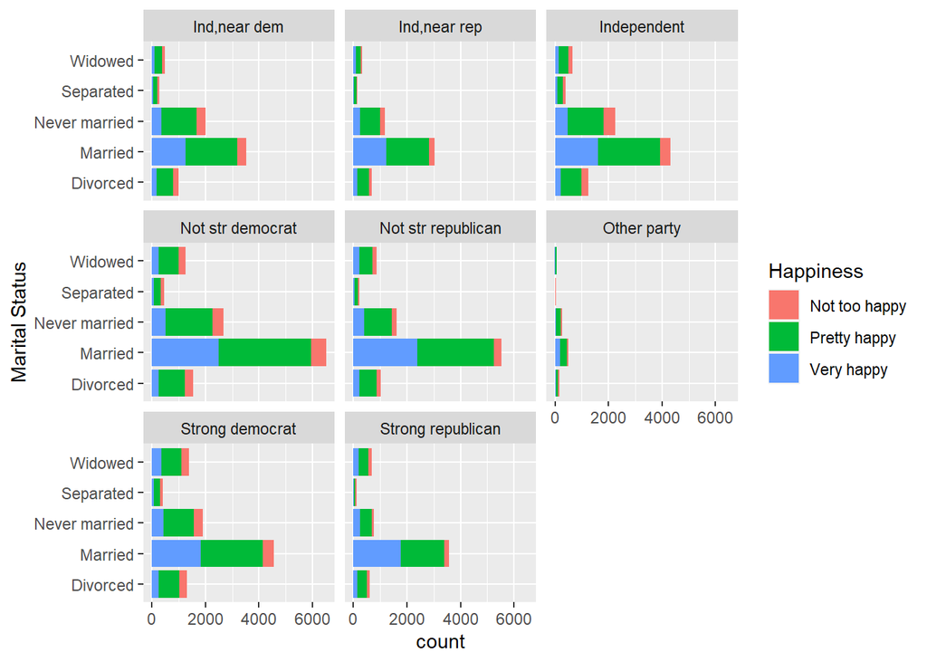

```r
newdat %>%
  select(happy, marital, partyid) %>%
  filter(happy %in% c("Not too happy", "Pretty happy", "Very happy")) %>%
  drop_na() %>%
  ggplot(aes(x=marital, fill=happy)) + geom_bar(position='stack') + labs(fill="Happiness", x="Marital Status") + facet_wrap(~partyid) + coord_flip()
```

5. How is marital status related to the education of a respondent? What are possible reasons accounting for the patterns you see?

```
## # A tibble: 5 x 2
##   marital       AVEedu
##   <chr>          <dbl>
## 1 Divorced        13.1
## 2 Married         13.0
## 3 Never married   13.4
## 4 Separated       11.9
## 5 Widowed         11.2
```

[figure not shown]

```
In general, from data we can see people who never married have the highest average educarion level. This shows that the higher education level, the harder for people to find a good marriage. Because people with high education level may increase their requirement for marriage.
```

6. Explore two more interesting questions, and answer those questions using the GSS data.

Question 2: What is the relationship between respondents’ total family income and their happiness?

```
## # A tibble: 12 x 2
##    fincome        CountHappy
##    <chr>               <int>
##  1 $1000 to 2999        1268
##  2 $10000 - 14999       6164
##  3 $15000 - 19999       4756
##  4 $20000 - 24999       4869
##  5 $25000 or more      26308
##  6 $3000 to 3999        1225
##  7 $4000 to 4999        1119
##  8 $5000 to 5999        1224
##  9 $6000 to 6999        1145
## 10 $7000 to 7999        1221
## 11 $8000 to 9999        2082
## 12 Lt $1000              714
```

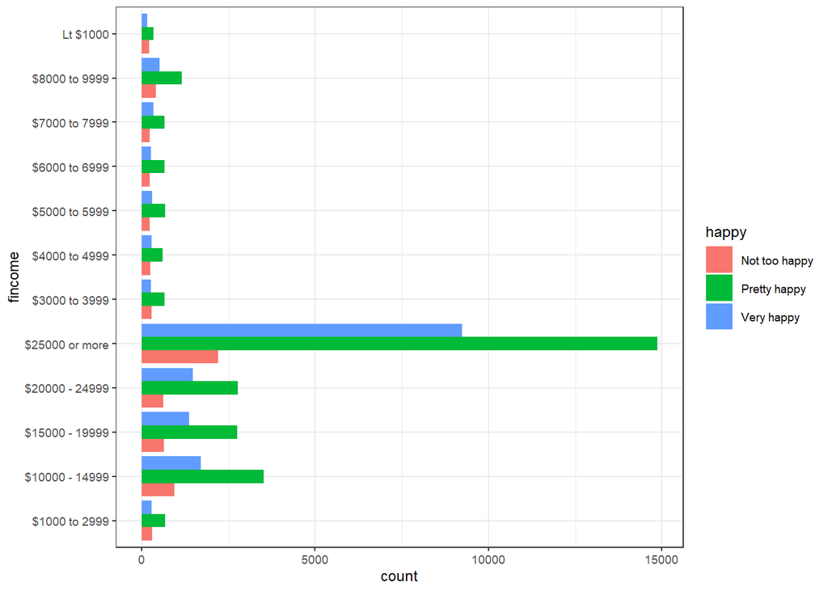

[output not shown]